# matplotlib-600-tips

```python
import numpy as np
import matplotlib.pyplot as plt
```

## matplotlib技巧集

### 使用agg后台在图像上绘图

```python
import numpy as np
from matplotlib.backends.backend_agg import RendererAgg

w, h = 250, 250
renderer = RendererAgg(w, h, 90)
buf = renderer.buffer_rgba()
arr = np.frombuffer(buf, np.uint8).reshape(h, w, -1)
print((arr.shape))
```

```
(250, 250, 4)
```

```python
from matplotlib.path import Path
from matplotlib import transforms

path_data = [
    (Path.MOVETO, (179, 1)),
    (Path.CURVE4, (117, 75)),
    (Path.CURVE4, (12, 230)),
    (Path.CURVE4, (118, 230)),
    (Path.LINETO, (142, 187)),
    (Path.CURVE4, (210, 290)),
    (Path.CURVE4, (250, 132)),
    (Path.CURVE4, (200, 105)),
    (Path.CLOSEPOLY, (179, 1)),
]

code, points = list(zip(*path_data))
path = Path(points, code)

gc = renderer.new_gc()
gc.set_linewidth(2)
gc.set_foreground((1, 0, 0))
gc.set_antialiased(True)
renderer.draw_path(gc, path, transforms.IdentityTransform(), (0, 1, 0))
```

```python
from matplotlib.patches import Circle
from matplotlib.text import Text

c = Circle((w/2, h/2), 50, edgecolor="blue", facecolor="yellow", linewidth=2, alpha=0.5)
c.draw(renderer)

text = Text(w/2, h/2, "Circle", va="center", ha="center")
text.figure = renderer
text.draw(renderer)
```

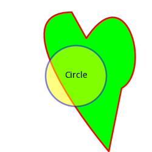

```python
#%fig=直接使用RendererAgg绘图
from io import BytesIO
from IPython.display import display_png
png_buf = BytesIO()
plt.imsave(png_buf, arr, format="png")
display_png(png_buf.getvalue(), raw=True)
```

> **SOURCE**

> `scpy2.matplotlib.ImageDrawer`：使用`RendererAgg`直接在图像上绘图，方便用户在图像上标注信息。

[figure not shown]

```python
#%fig=使用本书提供的ImageDrawer在图像上绘图
from scpy2.matplotlib import ImageDrawer
img = plt.imread("vinci_target.png")
drawer = ImageDrawer(img)
drawer.set_parameters(lw=2, color="white", alpha=0.5)
drawer.line(8, 60, 280, 60)
drawer.circle(123, 130, 50, facecolor="yellow", lw=4)
drawer.markers("x", [82, 182], [218, 218], [50, 100])
drawer.rectangle(81, 330, 100, 30, facecolor="blue")
drawer.text(10, 50, u"Mona Lisa", fontsize=40)
drawer.ellipse(119, 255, 200, 100, 100, facecolor="red")
%array_image drawer.to_array()
```

### 响应鼠标与键盘事件

> **TIP**

> 为了在Notebook中执行本节代码，需要启动GUI事件处理线程，例如执行`%gui qt`和`%matplotlib qt`，将启动Qt的GUI线程，并将`Qt4Agg`设置为matplotlib的绘图后台。如果希望切换到嵌入模式，可以再执行`%matplotlib inline`。

```python
%gui qt
%matplotlib qt
```

#### 键盘事件

> **SOURCE**

> `scpy2.matplotlib.key_event_show_key`：显示触发键盘按键事件的按键名称。

```python
#%hide
%exec_python -m scpy2.matplotlib.key_event_show_key
```

```python
import sys

fig, ax = plt.subplots()

def on_key_press(event):
    print((event.key))
    sys.stdout.flush()

fig.canvas.mpl_connect('key_press_event', on_key_press);
```

```
control
ctrl+a
alt
alt+l
```

```python
for key, funcs in list(fig.canvas.callbacks.callbacks.items()):
    print(key)
    for cid, wrap in sorted(funcs.items()):
        func = wrap.func
        print(("    {0}:{1}.{2}".format(cid, func.__module__, func)))
```

```
key_press_event
    3:matplotlib.backend_bases.<function key_press at 0x093A4C30>
    6:__main__.<function on_key_press at 0x09B05FB0>
motion_notify_event
    4:matplotlib.backend_bases.<function mouse_move at 0x093A4FB0>
scroll_event
    2:matplotlib.backend_bases.<function pick at 0x093A40F0>
button_press_event
    1:matplotlib.backend_bases.<function pick at 0x093A40F0>
```

> **SOURCE**

> `scpy2.matplotlib.key_event_change_color`：通过按键修改曲线的颜色。

```python
#%hide
%exec_python -m scpy2.matplotlib.key_event_change_color
```

```python
fig, ax = plt.subplots()
x = np.linspace(0, 10, 1000)
line, = ax.plot(x, np.sin(x))

def on_key_press(event):
    if event.key in 'rgbcmyk':
        line.set_color(event.key)  #❶
    fig.canvas.draw_idle()         #❷

fig.canvas.mpl_disconnect(fig.canvas.manager.key_press_handler_id)
fig.canvas.mpl_connect('key_press_event', on_key_press);
```

#### 鼠标事件

> **SOURCE**

> `scpy2.matplotlib.mouse_event_show_info`：显示子图中的鼠标事件的各种信息。

```python
#%hide
%exec_python -m scpy2.matplotlib.mouse_event_show_info
```

```python
import sys
fig, ax = plt.subplots()
text = ax.text(0.5, 0.5, "event", ha="center", va="center", fontdict={"size":20})

def on_mouse(event):
    global e
    e = event
    info = "{}\nButton:{}\nFig x,y:{}, {}\nData x,y:{:3.2f}, {:3.2f}".format(
    event.name, event.button, event.x, event.y, event.xdata, event.ydata)
    text.set_text(info)
    fig.canvas.draw()

fig.canvas.mpl_connect('button_press_event', on_mouse)
fig.canvas.mpl_connect('button_release_event', on_mouse)
fig.canvas.mpl_connect('motion_notify_event', on_mouse);
```

> **SOURCE**

> `scpy2.matplotlib.mouse_event_move_polygon`：演示通过鼠标移动`Patch`对象。

```python
#%hide
%exec_python -m scpy2.matplotlib.mouse_event_move_polygon
```

```python
from numpy.random import rand, randint
from matplotlib.patches import RegularPolygon


class PatchMover(object):
    def __init__(self, ax):
        self.ax = ax
        self.selected_patch = None
        self.start_mouse_pos = None
        self.start_patch_pos = None

        fig = ax.figure
        fig.canvas.mpl_connect('button_press_event', self.on_press)
        fig.canvas.mpl_connect('button_release_event', self.on_release)
        fig.canvas.mpl_connect('motion_notify_event', self.on_motion)

    def on_press(self, event): #❶
        patches = self.ax.patches[:]
        patches.sort(key=lambda patch:patch.get_zorder())
        for patch in reversed(patches):
            if patch.contains_point((event.x, event.y)):  #❷
                self.selected_patch = patch
                self.start_mouse_pos = np.array([event.xdata, event.ydata])
                self.start_patch_pos = patch.xy
                break

    def on_motion(self, event):   #❸
        if self.selected_patch is not None:
            pos = np.array([event.xdata, event.ydata])
            self.selected_patch.xy = self.start_patch_pos + pos - self.start_mouse_pos
            self.ax.figure.canvas.draw_idle()   #❹

    def on_release(self, event):   #❺
        self.selected_patch = None


fig, ax = plt.subplots()
ax.set_aspect("equal")
for i in range(10):
    poly = RegularPolygon(rand(2), randint(3, 10), rand() * 0.1 + 0.1, facecolor=rand(3),
                          zorder=randint(10, 100))
    ax.add_patch(poly)
ax.relim()
ax.autoscale()
pm = PatchMover(ax)

plt.show()
```

#### 点选事件

> **SOURCE**

> `scpy2.matplotlib.pick_event_demo`：演示绘图对象的点选事件。

```python
#%hide
%exec_python -m scpy2.matplotlib.pick_event_demo
```

```python
fig, ax = plt.subplots()
rect = plt.Rectangle((np.pi, -0.5), 1, 1, fc=np.random.random(3), picker=True)
ax.add_patch(rect)
x = np.linspace(0, np.pi*2, 100)
y = np.sin(x)
line, = plt.plot(x, y, picker=8.0)

def on_pick(event):
    artist = event.artist
    if isinstance(artist, plt.Line2D):
        lw = artist.get_linewidth()
        artist.set_linewidth(lw % 5 + 1)
    else:
        artist.set_fc(np.random.random(3))
    fig.canvas.draw_idle()

fig.canvas.mpl_connect('pick_event', on_pick);
```

#### 实时高亮显示曲线

> **SOURCE**

> `scpy2.matplotlib.mouse_event_highlight_curve`：鼠标移动到曲线之上时高亮显示该曲线。

```python
#%hide
%exec_python -m scpy2.matplotlib.mouse_event_highlight_curve
```

```python
import matplotlib.pyplot as plt
import numpy as np

class CurveHighLighter(object):

    def __init__(self, ax, alpha=0.3, linewidth=3):
        self.ax = ax
        self.alpha = alpha
        self.linewidth = 3

        ax.figure.canvas.mpl_connect('motion_notify_event', self.on_move) #❶

    def highlight(self, target): #❷
        need_redraw = False
        if target is None:
            for line in self.ax.lines:
                line.set_alpha(1.0)
                if line.get_linewidth() != 1.0:
                    line.set_linewidth(1.0)
                    need_redraw = True
        else:
            for line in self.ax.lines:
                lw = self.linewidth if line is target else 1
                if line.get_linewidth() != lw:
                    line.set_linewidth(lw)
                    need_redraw = True
                alpha = 1.0 if lw == self.linewidth else self.alpha
                line.set_alpha(alpha)

        if need_redraw:
            self.ax.figure.canvas.draw_idle()

    def on_move(self, evt):
        ax = self.ax
        for line in ax.lines:
            if line.contains(evt)[0]: #❸
                self.highlight(line)
                break
        else:
            self.highlight(None)

fig, ax = plt.subplots()
x = np.linspace(0, 50, 300)

from scipy.special import jn

for i in range(1, 10):
    ax.plot(x, jn(i, x))

ch = CurveHighLighter(ax)
```

### 动画

```python
import numpy as np
import matplotlib.pyplot as plt

fig, ax = plt.subplots()
x = np.linspace(0, 10, 1000)
line, = ax.plot(x, np.sin(x), lw=2)

def update_data(line):
    x[:] += 0.1
    line.set_ydata(np.sin(x)) #❷
    fig.canvas.draw()         #❸

timer = fig.canvas.new_timer(interval=50) #❶
timer.add_callback(update_data, line)
timer.start()
```

#### 使用缓存快速重绘图表

```python
fig, ax = plt.subplots()
x = np.linspace(0, 10, 1000)
line, = ax.plot(x, np.sin(x), lw=2, animated=True) #❶

fig.canvas.draw() #❷
background = fig.canvas.copy_from_bbox(ax.bbox) #❸

def update_data(line):
    x[:] += 0.1
    line.set_ydata(np.sin(x))
    fig.canvas.restore_region(background)  #❹
    ax.draw_artist(line)     #❺
    fig.canvas.blit(ax.bbox) #❻

timer = fig.canvas.new_timer(interval=50)
timer.add_callback(update_data, line)
timer.start()
```

#### animation模块

```python
import numpy as np
from matplotlib import pyplot as plt
from matplotlib.animation import FuncAnimation

fig, ax = plt.subplots()

x = np.linspace(0, 4*np.pi, 200)
y = np.sin(x)
line, = ax.plot(x, y, lw=2, animated=True) #❶

def update_line(i):
    y = np.sin(x + i*2*np.pi/100)
    line.set_ydata(y)
    return [line] #❷

ani = FuncAnimation(fig, update_line, blit=True, interval=25, frames=100) #❸
```

> **WARNING**

> matplotlib会使用系统中安装的视频压缩软件（如`ffmpeg.exe`）生成视频文件。请读者确认视频压缩软件的可执行文件的路径是否在`PATH`环境变量中。

```python
ani.save('sin_wave.mp4', fps=25)
```

### 添加GUI面板

> **SOURCE**

> `scpy2.matplotlib.gui_panel`：提供了TK与QT界面库的滑标控件面板类`TkSliderPanel`和`QtSliderPanel`。`tk_panel_demo.py`和`qt_panel_demo.py`为其演示程序。

```python
%gui tk
import numpy as np
import matplotlib

matplotlib.use("TkAgg")  #❶

import pylab as pl

def exp_sin(x, A, f, z, p): #❷
    return A * np.sin(2 * np.pi * f * x + p)  * np.exp(z * x)

fig, ax = pl.subplots()

x = np.linspace(1e-6, 1, 500)
pars = {"A":1.0, "f":2, "z":-0.2, "p":0}
y = exp_sin(x, **pars)

line, = pl.plot(x, y)

def update(**kw): #❸
    y = exp_sin(x, **kw)
    line.set_data(x, y) #❹
    ax.relim()
    ax.autoscale_view()
    fig.canvas.draw_idle() #❺

from scpy2.matplotlib.gui_panel import TkSliderPanel

panel = TkSliderPanel(fig,  #❻
                      [("A", 0, 10), ("f", 0, 10), ("z", -3, 0), ("p", 0, 2*np.pi)],
                      update, cols=2, min_value_width=80)
panel.set_parameters(**pars) #❼
fig.show() #❽
```

```python
#%hide
%exec_python -m scpy2.matplotlib.tk_panel_demo
```

```python
#%hide
%exec_python -m scpy2.matplotlib.qt_panel_demo
```